# 10 minutes to pandas

十分钟搞定Pandas

这是对官方文档[10 Minutes to pandas](http://pandas.pydata.org/pandas-docs/stable/getting_started/10min.html)的简单翻译.

[figure not shown]

*Photo by Carlos Muza on Unsplash*

这是对pandas的简要介绍，主要面向新用户。更详细的信息你可以看这里：[Cookbook](http://pandas.pydata.org/pandas-docs/stable/user_guide/cookbook.html#cookbook)

按照惯例，我们导入需要的packages:

```python
import numpy as np
import pandas as pd
```

# 创建对象

Documentation： [Data Structure Intro section](http://pandas.pydata.org/pandas-docs/stable/getting_started/dsintro.html#dsintro)

通过传递一个包含多个值的list来创建一个 Series，Pandas默认会创建一个整型索引。

```python
s = pd.Series([1,3,5,np.nan,6,8])
```

```python
s
```

```
0    1.0
1    3.0
2    5.0
3    NaN
4    6.0
5    8.0
dtype: float64
```

传递一个NumPy数组来创建一个DataFrame，以日期为索引并且给每列添加标签。

```python
dates = pd.date_range(start='20130101',periods=6)
```

```python
dates
```

```
DatetimeIndex(['2013-01-01', '2013-01-02', '2013-01-03', '2013-01-04',
               '2013-01-05', '2013-01-06'],
              dtype='datetime64[ns]', freq='D')
```

```python
df = pd.DataFrame(np.random.randn(6,4),index=dates,columns=list('ABCD'))
df
```

|  | A | B | C | D |
| --- | --- | --- | --- | --- |
| 2013-01-01 | 1.708772 | -0.099085 | 1.456107 | -0.658194 |
| 2013-01-02 | -0.619644 | -0.356412 | -0.166210 | -0.213981 |
| 2013-01-03 | -0.805873 | -2.156762 | 1.321881 | -0.726371 |
| 2013-01-04 | 1.638938 | -1.083907 | -0.508793 | -1.056083 |
| 2013-01-05 | 0.162016 | 0.248454 | 0.656046 | 1.841630 |
| 2013-01-06 | 0.749583 | 0.601788 | 0.254840 | 1.300131 |

传递一个可以转变成类似series的字典对象来创建DataFrame。

```python
df2 = pd.DataFrame({
    'A':1,
    'B':pd.Timestamp('20130102'),
    'C':pd.Series(1,index=list(range(4)),dtype='float32'),
    'D':np.array([3]*4,dtype='int32'),
    'E':pd.Categorical(["test","train","test","train"]),
    'F':'foo'
})
```

```python
df2
```

|  | A | B | C | D | E | F |
| --- | --- | --- | --- | --- | --- | --- |
| 0 | 1 | 2013-01-02 | 1.0 | 3 | test | foo |
| 1 | 1 | 2013-01-02 | 1.0 | 3 | train | foo |
| 2 | 1 | 2013-01-02 | 1.0 | 3 | test | foo |
| 3 | 1 | 2013-01-02 | 1.0 | 3 | train | foo |

DataFrame中的每一列有不同的数据类型。

```python
df2.dtypes
```

```
A             int64
B    datetime64[ns]
C           float32
D             int32
E          category
F            object
dtype: object
```

如果你使用IPython，tab自动补全功能对列名（还有公共属性）是有效的。

# 查看数据

Documentation：[Basics section](http://pandas.pydata.org/pandas-docs/stable/getting_started/basics.html#basics)

查看frame的前几行和后几行。

```python
df.head()
```

|  | A | B | C | D |
| --- | --- | --- | --- | --- |
| 2013-01-01 | 1.708772 | -0.099085 | 1.456107 | -0.658194 |
| 2013-01-02 | -0.619644 | -0.356412 | -0.166210 | -0.213981 |
| 2013-01-03 | -0.805873 | -2.156762 | 1.321881 | -0.726371 |
| 2013-01-04 | 1.638938 | -1.083907 | -0.508793 | -1.056083 |
| 2013-01-05 | 0.162016 | 0.248454 | 0.656046 | 1.841630 |

```python
df.tail(3)
```

|  | A | B | C | D |
| --- | --- | --- | --- | --- |
| 2013-01-04 | 1.638938 | -1.083907 | -0.508793 | -1.056083 |
| 2013-01-05 | 0.162016 | 0.248454 | 0.656046 | 1.841630 |
| 2013-01-06 | 0.749583 | 0.601788 | 0.254840 | 1.300131 |

查看索引，列名。

```python
df.index
```

```
DatetimeIndex(['2013-01-01', '2013-01-02', '2013-01-03', '2013-01-04',
               '2013-01-05', '2013-01-06'],
              dtype='datetime64[ns]', freq='D')
```

```python
df.columns
```

```
Index(['A', 'B', 'C', 'D'], dtype='object')
```

[DataFrame.to_numpy()](http://pandas.pydata.org/pandas-docs/stable/reference/api/pandas.DataFrame.to_numpy.html#pandas.DataFrame.to_numpy)可以将数据转换为NumPy。值得注意的是，如果DataFrame每一列的数据类型不同，那么该操作的代价十分昂贵,这归根结底还是panda和NumPy之间的根本区别：整个NumPy数组的数据类型是同一个，而Pandas DataFrame每一列有一种数据类型。当你调用DataFrame.to_numpy()时，pandas将寻找一种NumPy dtype，这种NumPy dtype可以“容纳”DataFrame中所有dtype。最终可能找到的是object类，此时就需要将DataFrame每个值转换为Python对象。

对于df，由于DataFrame中都是浮点数，所以DataFrame.to_numpy()非常快且不需要复制数据。

```python
# df.to_numpy()  -> AttributeError: 'DataFrame' object has no attribute 'to_numpy'
df.as_matrix()
```

```
array([[ 1.70877179, -0.09908468,  1.45610746, -0.658194  ],
       [-0.61964412, -0.35641213, -0.16620967, -0.21398069],
       [-0.80587297, -2.15676192,  1.3218813 , -0.72637134],
       [ 1.63893788, -1.08390745, -0.50879269, -1.05608331],
       [ 0.16201636,  0.24845441,  0.6560461 ,  1.84163014],
       [ 0.74958325,  0.60178783,  0.25484011,  1.30013126]])
```

对于df2，DataFrame有多种数据类型，所以DataFrame.to_numpy()的代价昂贵。

```python
# df2.to_numpy() -> AttributeError: 'DataFrame' object has no attribute 'to_numpy'
df2.as_matrix()
```

```
array([[1, Timestamp('2013-01-02 00:00:00'), 1.0, 3, 'test', 'foo'],
       [1, Timestamp('2013-01-02 00:00:00'), 1.0, 3, 'train', 'foo'],
       [1, Timestamp('2013-01-02 00:00:00'), 1.0, 3, 'test', 'foo'],
       [1, Timestamp('2013-01-02 00:00:00'), 1.0, 3, 'train', 'foo']],
      dtype=object)
```

**注意：**DataFrame.to_numpy()的输出不包括索引和列标签。

[describe()](http://pandas.pydata.org/pandas-docs/stable/reference/api/pandas.DataFrame.describe.html#pandas.DataFrame.describe)函数对数据进行快速的统计总结

```python
df.describe()
```

|  | A | B | C | D |
| --- | --- | --- | --- | --- |
| count | 6.000000 | 6.000000 | 6.000000 | 6.000000 |
| mean | 0.472299 | -0.474321 | 0.502312 | 0.081189 |
| std | 1.085278 | 1.003725 | 0.791903 | 1.197024 |
| min | -0.805873 | -2.156762 | -0.508793 | -1.056083 |
| 25% | -0.424229 | -0.902034 | -0.060947 | -0.709327 |
| 50% | 0.455800 | -0.227748 | 0.455443 | -0.436087 |
| 75% | 1.416599 | 0.161570 | 1.155422 | 0.921603 |
| max | 1.708772 | 0.601788 | 1.456107 | 1.841630 |

数据转置

```python
df.T
```

|  | 2013-01-01 00:00:00 | 2013-01-02 00:00:00 | 2013-01-03 00:00:00 | 2013-01-04 00:00:00 | 2013-01-05 00:00:00 | 2013-01-06 00:00:00 |
| --- | --- | --- | --- | --- | --- | --- |
| A | 1.708772 | -0.619644 | -0.805873 | 1.638938 | 0.162016 | 0.749583 |
| B | -0.099085 | -0.356412 | -2.156762 | -1.083907 | 0.248454 | 0.601788 |
| C | 1.456107 | -0.166210 | 1.321881 | -0.508793 | 0.656046 | 0.254840 |
| D | -0.658194 | -0.213981 | -0.726371 | -1.056083 | 1.841630 | 1.300131 |

按轴排序

```python
df.sort_index(axis=1,ascending=False) # Sort object by labels (along an axis)
```

|  | D | C | B | A |
| --- | --- | --- | --- | --- |
| 2013-01-01 | -0.658194 | 1.456107 | -0.099085 | 1.708772 |
| 2013-01-02 | -0.213981 | -0.166210 | -0.356412 | -0.619644 |
| 2013-01-03 | -0.726371 | 1.321881 | -2.156762 | -0.805873 |
| 2013-01-04 | -1.056083 | -0.508793 | -1.083907 | 1.638938 |
| 2013-01-05 | 1.841630 | 0.656046 | 0.248454 | 0.162016 |
| 2013-01-06 | 1.300131 | 0.254840 | 0.601788 | 0.749583 |

按值排序

```python
df.sort_values(by='B')
```

|  | A | B | C | D |
| --- | --- | --- | --- | --- |
| 2013-01-03 | -0.805873 | -2.156762 | 1.321881 | -0.726371 |
| 2013-01-04 | 1.638938 | -1.083907 | -0.508793 | -1.056083 |
| 2013-01-02 | -0.619644 | -0.356412 | -0.166210 | -0.213981 |
| 2013-01-01 | 1.708772 | -0.099085 | 1.456107 | -0.658194 |
| 2013-01-05 | 0.162016 | 0.248454 | 0.656046 | 1.841630 |
| 2013-01-06 | 0.749583 | 0.601788 | 0.254840 | 1.300131 |

# 选择

**注意：**虽然用于选择和设置的标准Python / Numpy表达式非常直观，并且便于交互工作，但是对于工程代码，我们推荐优化的pandas数据访问方法,.at、.iat、.loc和.iloc

Documentation:

[Indexing and Selecting Data](http://pandas.pydata.org/pandas-docs/stable/user_guide/indexing.html#indexing)

[MultiIndex / Advanced Indexing](http://pandas.pydata.org/pandas-docs/stable/user_guide/advanced.html#advanced)

## 获取

选择单列，返回Series，等同df.A

```python
df['A']
```

```
2013-01-01    1.708772
2013-01-02   -0.619644
2013-01-03   -0.805873
2013-01-04    1.638938
2013-01-05    0.162016
2013-01-06    0.749583
Freq: D, Name: A, dtype: float64
```

通过[]选择，这会对行(row)进行切片

```python
df[0:3]
```

|  | A | B | C | D |
| --- | --- | --- | --- | --- |
| 2013-01-01 | 1.708772 | -0.099085 | 1.456107 | -0.658194 |
| 2013-01-02 | -0.619644 | -0.356412 | -0.166210 | -0.213981 |
| 2013-01-03 | -0.805873 | -2.156762 | 1.321881 | -0.726371 |

```python
df['20130102':'20130104'] # by index ,include endpoints
```

|  | A | B | C | D |
| --- | --- | --- | --- | --- |
| 2013-01-02 | -0.619644 | -0.356412 | -0.166210 | -0.213981 |
| 2013-01-03 | -0.805873 | -2.156762 | 1.321881 | -0.726371 |
| 2013-01-04 | 1.638938 | -1.083907 | -0.508793 | -1.056083 |

## 通过标签选择

Documentation:

[Selection by Label](http://pandas.pydata.org/pandas-docs/stable/user_guide/indexing.html#indexing-label)

通过标签获得一个截面

```python
df.loc[dates[0]]
```

```
A    1.708772
B   -0.099085
C    1.456107
D   -0.658194
Name: 2013-01-01 00:00:00, dtype: float64
```

通过标签在多个轴上选择

```python
df.loc[:,['A','B']]
```

|  | A | B |
| --- | --- | --- |
| 2013-01-01 | 1.708772 | -0.099085 |
| 2013-01-02 | -0.619644 | -0.356412 |
| 2013-01-03 | -0.805873 | -2.156762 |
| 2013-01-04 | 1.638938 | -1.083907 |
| 2013-01-05 | 0.162016 | 0.248454 |
| 2013-01-06 | 0.749583 | 0.601788 |

标签切片，包括两端点

```python
df.loc['20130102':'20130104',['A','B']]
```

|  | A | B |
| --- | --- | --- |
| 2013-01-02 | -0.619644 | -0.356412 |
| 2013-01-03 | -0.805873 | -2.156762 |
| 2013-01-04 | 1.638938 | -1.083907 |

缩小返回对象的维数

```python
df.loc['20130102',['A','B']]
```

```
A   -0.619644
B   -0.356412
Name: 2013-01-02 00:00:00, dtype: float64
```

得到一个标量

```python
df.loc[dates[0],'A'] # notes the differences with df.loc[dates[0],['A']]
```

```
1.708771788186979
```

快速得到一个标量（与之前的方法等同）

```python
# df.at[dates[0],['A']] -> TypeError:unhashable type: 'list'
df.at[dates[0],'A']
```

```
1.708771788186979
```

## 通过位置选择

Documentation： [Selection by Position](http://pandas.pydata.org/pandas-docs/stable/user_guide/indexing.html#indexing-integer)

传入整数进行位置选择

```python
df.iloc[3] # get the 3rd(count from 0) row
```

```
A    1.638938
B   -1.083907
C   -0.508793
D   -1.056083
Name: 2013-01-04 00:00:00, dtype: float64
```

整数切片，与numpy/python相似

```python
df.iloc[3:5,0:2] # not include endpoints
```

|  | A | B |
| --- | --- | --- |
| 2013-01-04 | 1.638938 | -1.083907 |
| 2013-01-05 | 0.162016 | 0.248454 |

通过位置列表选择，与numpy/python相似

```python
df.iloc[[1,2,4],[0,2]]
```

|  | A | C |
| --- | --- | --- |
| 2013-01-02 | -0.619644 | -0.166210 |
| 2013-01-03 | -0.805873 | 1.321881 |
| 2013-01-05 | 0.162016 | 0.656046 |

行切片

```python
df.iloc[1:3,:]
```

|  | A | B | C | D |
| --- | --- | --- | --- | --- |
| 2013-01-02 | -0.619644 | -0.356412 | -0.166210 | -0.213981 |
| 2013-01-03 | -0.805873 | -2.156762 | 1.321881 | -0.726371 |

列切片

```python
df.iloc[:,1:3]
```

|  | B | C |
| --- | --- | --- |
| 2013-01-01 | -0.099085 | 1.456107 |
| 2013-01-02 | -0.356412 | -0.166210 |
| 2013-01-03 | -2.156762 | 1.321881 |
| 2013-01-04 | -1.083907 | -0.508793 |
| 2013-01-05 | 0.248454 | 0.656046 |
| 2013-01-06 | 0.601788 | 0.254840 |

显式获取某个值

```python
df.iloc[1,1]
```

```
-0.3564121268432123
```

更快的获取某个值

```python
df.iat[1,1]
```

```
-0.3564121268432123
```

## 布尔索引

使用某一列的值来选择数据

```python
df[df.A > 0]
```

|  | A | B | C | D |
| --- | --- | --- | --- | --- |
| 2013-01-01 | 1.708772 | -0.099085 | 1.456107 | -0.658194 |
| 2013-01-04 | 1.638938 | -1.083907 | -0.508793 | -1.056083 |
| 2013-01-05 | 0.162016 | 0.248454 | 0.656046 | 1.841630 |
| 2013-01-06 | 0.749583 | 0.601788 | 0.254840 | 1.300131 |

```python
df
```

|  | A | B | C | D |
| --- | --- | --- | --- | --- |
| 2013-01-01 | 1.708772 | -0.099085 | 1.456107 | -0.658194 |
| 2013-01-02 | -0.619644 | -0.356412 | -0.166210 | -0.213981 |
| 2013-01-03 | -0.805873 | -2.156762 | 1.321881 | -0.726371 |
| 2013-01-04 | 1.638938 | -1.083907 | -0.508793 | -1.056083 |
| 2013-01-05 | 0.162016 | 0.248454 | 0.656046 | 1.841630 |
| 2013-01-06 | 0.749583 | 0.601788 | 0.254840 | 1.300131 |

选择DataFrame中满足布尔条件的值

```python
df[df>0]
```

|  | A | B | C | D |
| --- | --- | --- | --- | --- |
| 2013-01-01 | 1.708772 | NaN | 1.456107 | NaN |
| 2013-01-02 | NaN | NaN | NaN | NaN |
| 2013-01-03 | NaN | NaN | 1.321881 | NaN |
| 2013-01-04 | 1.638938 | NaN | NaN | NaN |
| 2013-01-05 | 0.162016 | 0.248454 | 0.656046 | 1.841630 |
| 2013-01-06 | 0.749583 | 0.601788 | 0.254840 | 1.300131 |

使用[isin()](http://pandas.pydata.org/pandas-docs/stable/reference/api/pandas.Series.isin.html#pandas.Series.isin)方法进行过滤

```python
df2 = df.copy()
```

```python
df2['E'] = ['one','one','two','three','four','three']
```

```python
df2
```

|  | A | B | C | D | E |
| --- | --- | --- | --- | --- | --- |
| 2013-01-01 | 1.708772 | -0.099085 | 1.456107 | -0.658194 | one |
| 2013-01-02 | -0.619644 | -0.356412 | -0.166210 | -0.213981 | one |
| 2013-01-03 | -0.805873 | -2.156762 | 1.321881 | -0.726371 | two |
| 2013-01-04 | 1.638938 | -1.083907 | -0.508793 | -1.056083 | three |
| 2013-01-05 | 0.162016 | 0.248454 | 0.656046 | 1.841630 | four |
| 2013-01-06 | 0.749583 | 0.601788 | 0.254840 | 1.300131 | three |

```python
df2[df2['E'].isin(['two','four'])]
```

|  | A | B | C | D | E |
| --- | --- | --- | --- | --- | --- |
| 2013-01-03 | -0.805873 | -2.156762 | 1.321881 | -0.726371 | two |
| 2013-01-05 | 0.162016 | 0.248454 | 0.656046 | 1.841630 | four |

## 设置

设置新列并通过索引自动对齐数据。

```python
s1 = pd.Series([1,2,3,4,5,6],index=pd.date_range(start='20130102',periods=6))
```

```python
s1
```

```
2013-01-02    1
2013-01-03    2
2013-01-04    3
2013-01-05    4
2013-01-06    5
2013-01-07    6
Freq: D, dtype: int64
```

```python
df['F']=s1
```

通过标签赋值：

```python
df.at[dates[0],'A']=0
```

通过位置赋值：

```python
df.iat[0,1]=0
```

通过一个NumPy数组赋值：

```python
df.loc[:,'D'] = np.array([5]*len(df)) # equals to 'df.at[:,'D'] = np.array([5]*len(df))'
```

所有赋值操作之后的结果：

```python
df
```

|  | A | B | C | D | F |
| --- | --- | --- | --- | --- | --- |
| 2013-01-01 | 0.000000 | 0.000000 | 1.456107 | 5 | NaN |
| 2013-01-02 | -0.619644 | -0.356412 | -0.166210 | 5 | 1.0 |
| 2013-01-03 | -0.805873 | -2.156762 | 1.321881 | 5 | 2.0 |
| 2013-01-04 | 1.638938 | -1.083907 | -0.508793 | 5 | 3.0 |
| 2013-01-05 | 0.162016 | 0.248454 | 0.656046 | 5 | 4.0 |
| 2013-01-06 | 0.749583 | 0.601788 | 0.254840 | 5 | 5.0 |

通过where操作赋值

```python
df2 = df.copy()
```

```python
df2[df2>0]=-df2
```

```python
df2
```

|  | A | B | C | D | F |
| --- | --- | --- | --- | --- | --- |
| 2013-01-01 | 0.000000 | 0.000000 | -1.456107 | -5 | NaN |
| 2013-01-02 | -0.619644 | -0.356412 | -0.166210 | -5 | -1.0 |
| 2013-01-03 | -0.805873 | -2.156762 | -1.321881 | -5 | -2.0 |
| 2013-01-04 | -1.638938 | -1.083907 | -0.508793 | -5 | -3.0 |
| 2013-01-05 | -0.162016 | -0.248454 | -0.656046 | -5 | -4.0 |
| 2013-01-06 | -0.749583 | -0.601788 | -0.254840 | -5 | -5.0 |

# 缺失数据

pandas主要使用np.nan来表示缺失值，并且计算时默认忽略。具体信息可以查看[Missing Data section](http://pandas.pydata.org/pandas-docs/stable/user_guide/missing_data.html#missing-data).

重新索引允许你改变/增加/删除某个周上的索引，返回原来数据的复本。

```python
df1 = df.reindex(index=dates[0:4],columns=list(df.columns)+['E'])
```

```python
df1.loc[dates[0]:dates[1],'E']=1
```

```python
df1
```

|  | A | B | C | D | F | E |
| --- | --- | --- | --- | --- | --- | --- |
| 2013-01-01 | 0.000000 | 0.000000 | 1.456107 | 5 | NaN | 1.0 |
| 2013-01-02 | -0.619644 | -0.356412 | -0.166210 | 5 | 1.0 | 1.0 |
| 2013-01-03 | -0.805873 | -2.156762 | 1.321881 | 5 | 2.0 | NaN |
| 2013-01-04 | 1.638938 | -1.083907 | -0.508793 | 5 | 3.0 | NaN |

丢掉任何含有缺失数据的行.

```python
df1.dropna(how='any')
```

|  | A | B | C | D | F | E |
| --- | --- | --- | --- | --- | --- | --- |
| 2013-01-02 | -0.619644 | -0.356412 | -0.16621 | 5 | 1.0 | 1.0 |

填充缺失数据.

```python
df1.fillna(value=5)
```

|  | A | B | C | D | F | E |
| --- | --- | --- | --- | --- | --- | --- |
| 2013-01-01 | 0.000000 | 0.000000 | 1.456107 | 5 | 5.0 | 1.0 |
| 2013-01-02 | -0.619644 | -0.356412 | -0.166210 | 5 | 1.0 | 1.0 |
| 2013-01-03 | -0.805873 | -2.156762 | 1.321881 | 5 | 2.0 | 5.0 |
| 2013-01-04 | 1.638938 | -1.083907 | -0.508793 | 5 | 3.0 | 5.0 |

获取值是否为nan的布尔mask.

```python
pd.isna(df1)
```

|  | A | B | C | D | F | E |
| --- | --- | --- | --- | --- | --- | --- |
| 2013-01-01 | False | False | False | False | True | False |
| 2013-01-02 | False | False | False | False | False | False |
| 2013-01-03 | False | False | False | False | False | True |
| 2013-01-04 | False | False | False | False | False | True |

# 操作

Documentation

[Basic section on Binary Ops](http://pandas.pydata.org/pandas-docs/stable/getting_started/basics.html#basics-binop).

## 数据统计

这些操作一般不包括缺失数据。

执行描述性统计：

```python
df.mean()
```

```
A    0.187503
B   -0.457807
C    0.502312
D    5.000000
F    3.000000
dtype: float64
```

沿其他轴执行相同操作：

```python
df.mean(1)
```

```
2013-01-01    1.614027
2013-01-02    0.971547
2013-01-03    1.071849
2013-01-04    1.609248
2013-01-05    2.013303
2013-01-06    2.321242
Freq: D, dtype: float64
```

对拥有不同维度和需要对齐的对象进行操作。

另外，pandas会自动沿着具体的维度进行广播。

```python
df
```

|  | A | B | C | D | F |
| --- | --- | --- | --- | --- | --- |
| 2013-01-01 | 0.000000 | 0.000000 | 1.456107 | 5 | NaN |
| 2013-01-02 | -0.619644 | -0.356412 | -0.166210 | 5 | 1.0 |
| 2013-01-03 | -0.805873 | -2.156762 | 1.321881 | 5 | 2.0 |
| 2013-01-04 | 1.638938 | -1.083907 | -0.508793 | 5 | 3.0 |
| 2013-01-05 | 0.162016 | 0.248454 | 0.656046 | 5 | 4.0 |
| 2013-01-06 | 0.749583 | 0.601788 | 0.254840 | 5 | 5.0 |

```python
s = pd.Series([1,3,5,np.nan,6,8],index=dates).shift(2)
s
```

```
2013-01-01    NaN
2013-01-02    NaN
2013-01-03    1.0
2013-01-04    3.0
2013-01-05    5.0
2013-01-06    NaN
Freq: D, dtype: float64
```

```python
df.sub(s,axis='index')
```

|  | A | B | C | D | F |
| --- | --- | --- | --- | --- | --- |
| 2013-01-01 | NaN | NaN | NaN | NaN | NaN |
| 2013-01-02 | NaN | NaN | NaN | NaN | NaN |
| 2013-01-03 | -1.805873 | -3.156762 | 0.321881 | 4.0 | 1.0 |
| 2013-01-04 | -1.361062 | -4.083907 | -3.508793 | 2.0 | 0.0 |
| 2013-01-05 | -4.837984 | -4.751546 | -4.343954 | 0.0 | -1.0 |
| 2013-01-06 | NaN | NaN | NaN | NaN | NaN |

## Apply

对数据应用函数.

```python
df
```

|  | A | B | C | D | F |
| --- | --- | --- | --- | --- | --- |
| 2013-01-01 | 0.000000 | 0.000000 | 1.456107 | 5 | NaN |
| 2013-01-02 | -0.619644 | -0.356412 | -0.166210 | 5 | 1.0 |
| 2013-01-03 | -0.805873 | -2.156762 | 1.321881 | 5 | 2.0 |
| 2013-01-04 | 1.638938 | -1.083907 | -0.508793 | 5 | 3.0 |
| 2013-01-05 | 0.162016 | 0.248454 | 0.656046 | 5 | 4.0 |
| 2013-01-06 | 0.749583 | 0.601788 | 0.254840 | 5 | 5.0 |

```python
df.apply(np.cumsum)
```

|  | A | B | C | D | F |
| --- | --- | --- | --- | --- | --- |
| 2013-01-01 | 0.000000 | 0.000000 | 1.456107 | 5 | NaN |
| 2013-01-02 | -0.619644 | -0.356412 | 1.289898 | 10 | 1.0 |
| 2013-01-03 | -1.425517 | -2.513174 | 2.611779 | 15 | 3.0 |
| 2013-01-04 | 0.213421 | -3.597081 | 2.102986 | 20 | 6.0 |
| 2013-01-05 | 0.375437 | -3.348627 | 2.759032 | 25 | 10.0 |
| 2013-01-06 | 1.125020 | -2.746839 | 3.013873 | 30 | 15.0 |

```python
df.apply(lambda x: x.max()-x.min()) # by column
```

```
A    2.444811
B    2.758550
C    1.964900
D    0.000000
F    4.000000
dtype: float64
```

## Histogramming

Documentation:

[Histogramming and Discretization](http://pandas.pydata.org/pandas-docs/stable/getting_started/basics.html#basics-discretization).

```python
s = pd.Series(np.random.randint(0,7,size=10))
```

```python
s
```

```
0    6
1    0
2    0
3    2
4    2
5    0
6    3
7    1
8    5
9    6
dtype: int32
```

```python
s.value_counts()
```

```
0    3
6    2
2    2
5    1
3    1
1    1
dtype: int64
```

## 字符串方法

Series的str属性中拥有一套字符串处理方法，这样可以很容易的对数组中的每个元素进行操作，如下面代码片段展示的那样。注意，str中的模式匹配默认使用[正则表达式](https://docs.python.org/3/library/re.html)(一些例子中总是使用它们)。详细信息参考 [Vectorized String Methods](http://pandas.pydata.org/pandas-docs/stable/user_guide/text.html#text-string-methods).

```python
s = pd.Series(['A', 'B', 'C', 'Aaba', 'Baca', np.nan, 'CABA', 'dog', 'cat'])
```

```python
s.str.lower()
```

```
0       a
1       b
2       c
3    aaba
4    baca
5     NaN
6    caba
7     dog
8     cat
dtype: object
```

# 合并

## concat

pandas提供了多种方法能够轻松地将Series，DataFrame和Panel对象组合在一起，并在join/merge类型操作的情况下，为索引和关系代数功能提供各种集合逻辑。

Documentation

[Merging section](http://pandas.pydata.org/pandas-docs/stable/user_guide/merging.html#merging)

使用[concat()](http://pandas.pydata.org/pandas-docs/stable/reference/api/pandas.concat.html#pandas.concat)连接pandas对象：

```python
df = pd.DataFrame(np.random.randn(10,4))
```

```python
df
```

|  | 0 | 1 | 2 | 3 |
| --- | --- | --- | --- | --- |
| 0 | 0.632281 | 0.197171 | 1.151424 | -2.016201 |
| 1 | -1.501439 | -1.601834 | -1.145645 | 0.612853 |
| 2 | -0.177891 | 0.434909 | -0.014438 | -0.491014 |
| 3 | 0.549951 | 0.177038 | 0.274717 | -0.099532 |
| 4 | -0.425276 | -1.092717 | -1.392336 | -0.053880 |
| 5 | 0.546599 | 1.144381 | 0.591823 | -0.312680 |
| 6 | 1.404046 | -1.060142 | -0.118142 | 1.263853 |
| 7 | 2.586101 | -1.707801 | -0.807261 | -0.691834 |
| 8 | 0.747401 | 2.087020 | 0.320357 | 2.615708 |
| 9 | 0.110792 | -0.445128 | -0.334518 | 0.109074 |

```python
# break it into pieces
pieces = [df[:3],df[3:7],df[7:]]
```

```python
pd.concat(pieces)
```

|  | 0 | 1 | 2 | 3 |
| --- | --- | --- | --- | --- |
| 0 | 0.632281 | 0.197171 | 1.151424 | -2.016201 |
| 1 | -1.501439 | -1.601834 | -1.145645 | 0.612853 |
| 2 | -0.177891 | 0.434909 | -0.014438 | -0.491014 |
| 3 | 0.549951 | 0.177038 | 0.274717 | -0.099532 |
| 4 | -0.425276 | -1.092717 | -1.392336 | -0.053880 |
| 5 | 0.546599 | 1.144381 | 0.591823 | -0.312680 |
| 6 | 1.404046 | -1.060142 | -0.118142 | 1.263853 |
| 7 | 2.586101 | -1.707801 | -0.807261 | -0.691834 |
| 8 | 0.747401 | 2.087020 | 0.320357 | 2.615708 |
| 9 | 0.110792 | -0.445128 | -0.334518 | 0.109074 |

## Join

SQL风格的合并。详细信息查看 [Database style joining](http://pandas.pydata.org/pandas-docs/stable/user_guide/merging.html#merging-join).

```python
left = pd.DataFrame({
    'key':['foo','foo'],
    'lval':[1,2]
})
```

```python
right = pd.DataFrame({
    'key':['foo','foo'],
    'rval':[4,5]
})
```

```python
left
```

|  | key | lval |
| --- | --- | --- |
| 0 | foo | 1 |
| 1 | foo | 2 |

```python
right
```

|  | key | rval |
| --- | --- | --- |
| 0 | foo | 4 |
| 1 | foo | 5 |

```python
pd.merge(left,right,on='key')
```

|  | key | lval | rval |
| --- | --- | --- | --- |
| 0 | foo | 1 | 4 |
| 1 | foo | 1 | 5 |
| 2 | foo | 2 | 4 |
| 3 | foo | 2 | 5 |

## Append

向DataFrame中增加行(rows)。详细信息查看 [Appending](http://pandas.pydata.org/pandas-docs/stable/user_guide/merging.html#merging-concatenation).

```python
df = pd.DataFrame(np.random.randn(8,4),columns=['A','B','C','D'])
```

```python
df
```

|  | A | B | C | D |
| --- | --- | --- | --- | --- |
| 0 | -0.329069 | 0.398785 | -0.254159 | -0.019744 |
| 1 | 0.330895 | -0.691581 | 0.475088 | -1.217655 |
| 2 | -0.191328 | -0.598345 | 0.831786 | 1.041902 |
| 3 | 0.086087 | -1.070079 | 1.848361 | -1.144558 |
| 4 | -0.129076 | -1.408955 | -1.569931 | 1.387020 |
| 5 | -0.988637 | 2.057011 | 0.570613 | 2.211449 |
| 6 | 2.266872 | -0.154424 | -0.161400 | -0.983472 |
| 7 | 3.308932 | -1.188970 | -0.024272 | -0.385015 |

```python
s = df.iloc[3]
```

```python
s
```

```
A    0.086087
B   -1.070079
C    1.848361
D   -1.144558
Name: 3, dtype: float64
```

```python
df.append(s,ignore_index=True)
```

|  | A | B | C | D |
| --- | --- | --- | --- | --- |
| 0 | -0.329069 | 0.398785 | -0.254159 | -0.019744 |
| 1 | 0.330895 | -0.691581 | 0.475088 | -1.217655 |
| 2 | -0.191328 | -0.598345 | 0.831786 | 1.041902 |
| 3 | 0.086087 | -1.070079 | 1.848361 | -1.144558 |
| 4 | -0.129076 | -1.408955 | -1.569931 | 1.387020 |
| 5 | -0.988637 | 2.057011 | 0.570613 | 2.211449 |
| 6 | 2.266872 | -0.154424 | -0.161400 | -0.983472 |
| 7 | 3.308932 | -1.188970 | -0.024272 | -0.385015 |
| 8 | 0.086087 | -1.070079 | 1.848361 | -1.144558 |

# Grouping

通过“group by”，我们指的是包含以下一个或多个步骤的过程:

```
· 通过一些标准将数据分成组

· 对每一个组分别使用函数

· 将结果组合成一个数据结构
```

Documentation：[Grouping section](http://pandas.pydata.org/pandas-docs/stable/user_guide/groupby.html#groupby).

```python
df = pd.DataFrame({
    'A':['foo','bar','foo','bar','foo','bar','foo','foo'],
    'B':['one','one','two','three','two','two','one','three'],
    'C':np.random.randn(8),
    'D':np.random.randn(8)
})
```

分组然后对分组结果使用[sum()](http://pandas.pydata.org/pandas-docs/stable/reference/api/pandas.DataFrame.sum.html#pandas.DataFrame.sum)函数.

```python
df.groupby('A').sum()
```

| A | C | D |
| --- | --- | --- |
| bar | -0.727497 | 0.204721 |
| foo | 3.320035 | 0.424011 |

通过多列分组形成一种层级索引，然后我们可以再次使用sum()函数.

```python
df.groupby(['A','B']).sum()
```

| A | B | C | D |
| --- | --- | --- | --- |
| bar | one | -0.406114 | 0.554903 |
|  | three | -1.275478 | 0.328224 |
|  | two | 0.954094 | -0.678406 |
| foo | one | 1.699431 | 0.688349 |
|  | three | 0.090777 | 0.646826 |
|  | two | 1.529828 | -0.911163 |

# Reshaping

Documentation:

[Hierarchical Indexing](http://pandas.pydata.org/pandas-docs/stable/user_guide/advanced.html#advanced-hierarchical)

[Reshaping](http://pandas.pydata.org/pandas-docs/stable/user_guide/reshaping.html#reshaping-stacking)

## Stack

```python
tuples = list(zip(*[['bar','bar','baz','baz','foo','foo','qux','qux'],
          ['one','two','one','two','one','two','one','two']
         ]))
```

```python
index = pd.MultiIndex.from_tuples(tuples,names=['first','second'])
```

```python
index
```

```
MultiIndex(levels=[['bar', 'baz', 'foo', 'qux'], ['one', 'two']],
           labels=[[0, 0, 1, 1, 2, 2, 3, 3], [0, 1, 0, 1, 0, 1, 0, 1]],
           names=['first', 'second'])
```

```python
df = pd.DataFrame(np.random.randn(8,2),index = index,columns=['A','B'])
```

```python
df
```

| first | second | A | B |
| --- | --- | --- | --- |
| bar | one | -1.812236 | 1.913991 |
|  | two | -1.828318 | -1.310490 |
| baz | one | 1.518540 | -2.997122 |
|  | two | -1.057783 | -1.108552 |
| foo | one | -0.465601 | 0.134633 |
|  | two | 1.812240 | 1.692612 |
| qux | one | 1.856457 | -0.077322 |
|  | two | 0.290688 | 0.638653 |

```python
df2 = df[:4]
```

```python
df2
```

| first | second | A | B |
| --- | --- | --- | --- |
| bar | one | -1.812236 | 1.913991 |
|  | two | -1.828318 | -1.310490 |
| baz | one | 1.518540 | -2.997122 |
|  | two | -1.057783 | -1.108552 |

[stack()](http://pandas.pydata.org/pandas-docs/stable/reference/api/pandas.DataFrame.stack.html#pandas.DataFrame.stack)方法把DataFrame列压缩一级.

```python
stacked = df2.stack()
```

```python
stacked
```

```
first  second
bar    one     A   -1.812236
               B    1.913991
       two     A   -1.828318
               B   -1.310490
baz    one     A    1.518540
               B   -2.997122
       two     A   -1.057783
               B   -1.108552
dtype: float64
```

[unstack()](http://pandas.pydata.org/pandas-docs/stable/reference/api/pandas.DataFrame.unstack.html#pandas.DataFrame.unstack)与stack()相反，默认“展开”最后一级:

```python
stacked.unstack()
```

| first | second | A | B |
| --- | --- | --- | --- |
| bar | one | -1.812236 | 1.913991 |
|  | two | -1.828318 | -1.310490 |
| baz | one | 1.518540 | -2.997122 |
|  | two | -1.057783 | -1.108552 |

```python
stacked.unstack(1)
```

| first | second | one | two |
| --- | --- | --- | --- |
| bar | A | -1.812236 | -1.828318 |
|  | B | 1.913991 | -1.310490 |
| baz | A | 1.518540 | -1.057783 |
|  | B | -2.997122 | -1.108552 |

```python
stacked.unstack(0)
```

| second | first | bar | baz |
| --- | --- | --- | --- |
| one | A | -1.812236 | 1.518540 |
|  | B | 1.913991 | -2.997122 |
| two | A | -1.828318 | -1.057783 |
|  | B | -1.310490 | -1.108552 |

## Pivot Tables

Documentation [Pivot Tables](http://pandas.pydata.org/pandas-docs/stable/user_guide/reshaping.html#reshaping-pivot)

```python
df = pd.DataFrame({'A': ['one', 'one', 'two', 'three'] * 3,
                   'B': ['A', 'B', 'C'] * 4,
                   'C': ['foo', 'foo', 'foo', 'bar', 'bar', 'bar'] * 2,
                   'D': np.random.randn(12),
                   'E': np.random.randn(12)})
```

```python
df
```

|  | A | B | C | D | E |
| --- | --- | --- | --- | --- | --- |
| 0 | one | A | foo | 0.123231 | -1.307459 |
| 1 | one | B | foo | 1.863790 | 0.039535 |
| 2 | two | C | foo | 0.205133 | 0.427756 |
| 3 | three | A | bar | -0.025754 | -0.702055 |
| 4 | one | B | bar | -1.401790 | 0.093159 |
| 5 | one | C | bar | 0.552561 | 0.148080 |
| 6 | two | A | foo | -0.973470 | -2.187867 |
| 7 | three | B | foo | -0.876298 | -1.055382 |
| 8 | one | C | foo | 0.731657 | 0.544333 |
| 9 | one | A | bar | -1.196583 | 0.408750 |
| 10 | two | B | bar | 0.639454 | 0.675046 |
| 11 | three | C | bar | -1.372270 | 1.860201 |

我们可以从这些数据中很容易地生成一个透视表：

```python
pd.pivot_table(df, values='D', index=['A', 'B'], columns=['C'])
```

| A | C B | bar | foo |
| --- | --- | --- | --- |
| one | A | -1.196583 | 0.123231 |
|  | B | -1.401790 | 1.863790 |
|  | C | 0.552561 | 0.731657 |
| three | A | -0.025754 | NaN |
|  | B | NaN | -0.876298 |
|  | C | -1.372270 | NaN |
| two | A | NaN | -0.973470 |
|  | B | 0.639454 | NaN |
|  | C | NaN | 0.205133 |

# Time Series

对于频率转换，pandas拥有简单，强大并且有效的功能来完成采样操作（例如，将秒级数据转换成以5分钟为单位的数据）。这在金融领域（不限于金融领域）非常常见。详细信息 [Time Series section](http://pandas.pydata.org/pandas-docs/stable/user_guide/timeseries.html#timeseries).

```python
rng = pd.date_range(start='1/1/2012',periods=100,freq='S')
```

```python
ts = pd.Series(np.random.randint(0,500,len(rng)),index=rng)
```

```python
ts.resample('5Min').sum()
```

```
2012-01-01    22304
Freq: 5T, dtype: int32
```

时区表示

```python
rng = pd.date_range('3/6/2012 00:00',periods=5,freq='D')
```

```python
ts = pd.Series(np.random.randn(len(rng)),rng)
```

```python
ts
```

```
2012-03-06   -0.828660
2012-03-07   -0.567928
2012-03-08   -1.038170
2012-03-09    0.161559
2012-03-10   -0.144575
Freq: D, dtype: float64
```

```python
ts_utc = ts.tz_localize('UTC')
ts_utc
```

```
2012-03-06 00:00:00+00:00   -0.828660
2012-03-07 00:00:00+00:00   -0.567928
2012-03-08 00:00:00+00:00   -1.038170
2012-03-09 00:00:00+00:00    0.161559
2012-03-10 00:00:00+00:00   -0.144575
Freq: D, dtype: float64
```

转换到另一个时区

```python
ts_utc.tz_convert('US/Eastern') # Note that is not tz_localize
```

```
2012-03-05 19:00:00-05:00   -0.828660
2012-03-06 19:00:00-05:00   -0.567928
2012-03-07 19:00:00-05:00   -1.038170
2012-03-08 19:00:00-05:00    0.161559
2012-03-09 19:00:00-05:00   -0.144575
Freq: D, dtype: float64
```

在时间跨度表示之间进行转换

```python
rng = pd.date_range('1/1/2012', periods=5, freq='M')
ts = pd.Series(np.random.randn(len(rng)), index=rng)
ts
```

```
2012-01-31    0.099546
2012-02-29    0.479817
2012-03-31    1.026356
2012-04-30   -1.171594
2012-05-31   -0.631454
Freq: M, dtype: float64
```

```python
ps = ts.to_period()
ps
```

```
2012-01    0.099546
2012-02    0.479817
2012-03    1.026356
2012-04   -1.171594
2012-05   -0.631454
Freq: M, dtype: float64
```

```python
ps.to_timestamp()
```

```
2012-01-01    0.099546
2012-02-01    0.479817
2012-03-01    1.026356
2012-04-01   -1.171594
2012-05-01   -0.631454
Freq: MS, dtype: float64
```

周期和时间戳之间的转换可以使用一些方便的算术函数。

```python
prng = pd.period_range('1990Q1', '2000Q4', freq='Q-NOV')
ts = pd.Series(np.random.randn(len(prng)), prng)
ts.index = (prng.asfreq('M', 'e') + 1).asfreq('H', 's') + 9
```

```python
ts.head()
```

```
1990-03-01 09:00   -0.112085
1990-06-01 09:00    0.323280
1990-09-01 09:00    0.592674
1990-12-01 09:00    1.103288
1991-03-01 09:00   -1.568474
Freq: H, dtype: float64
```

# Categoricals

DataFrame可以包含categorical数据，完整文档 [categorical introduction](http://pandas.pydata.org/pandas-docs/stable/user_guide/categorical.html#categorical)和 [API documentation](http://pandas.pydata.org/pandas-docs/stable/reference/arrays.html#api-arrays-categorical).

```python
df = pd.DataFrame({"id": [1, 2, 3, 4, 5, 6],
                   "raw_grade": ['a', 'b', 'b', 'a', 'a', 'e']})
```

```python
df
```

|  | id | raw_grade |
| --- | --- | --- |
| 0 | 1 | a |
| 1 | 2 | b |
| 2 | 3 | b |
| 3 | 4 | a |
| 4 | 5 | a |
| 5 | 6 | e |

将'raw_grade'转换为categorical数据类型.

```python
df["grade"] = df["raw_grade"].astype("category")
df["grade"]
```

```
0    a
1    b
2    b
3    a
4    a
5    e
Name: grade, dtype: category
Categories (3, object): [a, b, e]
```

将类别重命名为更有意义的名称.

```python
df["grade"].cat.categories = ["very good", "good", "very bad"]
```

```python
df
```

|  | id | raw_grade | grade |
| --- | --- | --- | --- |
| 0 | 1 | a | very good |
| 1 | 2 | b | good |
| 2 | 3 | b | good |
| 3 | 4 | a | very good |
| 4 | 5 | a | very good |
| 5 | 6 | e | very bad |

类别重新排序，并同时添加缺少的类别(Series .cat默认返回新的Series)

```python
df["grade"] = df["grade"].cat.set_categories(["very bad", "bad", "medium","good", "very good"])
```

```python
df["grade"]
```

```
0    very good
1         good
2         good
3    very good
4    very good
5     very bad
Name: grade, dtype: category
Categories (5, object): [very bad, bad, medium, good, very good]
```

排序是按类别中的顺序进行的，而不是按词法顺序进行的。

```python
df.sort_values(by="grade")
```

|  | id | raw_grade | grade |
| --- | --- | --- | --- |
| 5 | 6 | e | very bad |
| 1 | 2 | b | good |
| 2 | 3 | b | good |
| 0 | 1 | a | very good |
| 3 | 4 | a | very good |
| 4 | 5 | a | very good |

按类别列分组也会显示空类别

```python
df.groupby("grade").size()
```

```
grade
very bad     1
bad          0
medium       0
good         2
very good    3
dtype: int64
```

```python
df['grade']
```

```
0    very good
1         good
2         good
3    very good
4    very good
5     very bad
Name: grade, dtype: category
Categories (5, object): [very bad, bad, medium, good, very good]
```

# Plotting

Documentation:[Plotting](http://pandas.pydata.org/pandas-docs/stable/user_guide/visualization.html#visualization)

```python
ts = pd.Series(np.random.randn(1000),index=pd.date_range('1/1/2000', periods=1000))
ts = ts.cumsum()
```

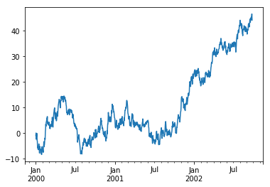

```python
%matplotlib inline
ts.plot()
```

在DataFrame上，[plot()](http://pandas.pydata.org/pandas-docs/stable/reference/api/pandas.DataFrame.plot.html#pandas.DataFrame.plot)方法可以方便地绘制所有带标签的列.

```python
df = pd.DataFrame(np.random.randn(1000, 4), index=ts.index,columns=['A', 'B', 'C', 'D'])
df= df.cumsum()
```

```python
import matplotlib.pyplot as plt
plt.figure()
```

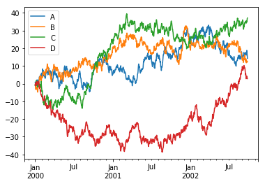

```python
df.plot()
plt.legend(loc='best') #e.g loc='upper left'/'upper right'
```

# 数据输入/输出

## CSV

输出到CSV文件

```python
df.to_csv('foo.csv')
```

从CSV文件读入.

```python
pd.read_csv('foo.csv')
```

|  | Unnamed: 0 | A | B | C | D |
| --- | --- | --- | --- | --- | --- |
| 0 | 2000-01-01 | 0.819171 | -0.928457 | -1.094900 | -0.538188 |
| 1 | 2000-01-02 | 0.860954 | -1.464523 | 0.278262 | -0.646317 |
| 2 | 2000-01-03 | 0.716599 | -2.061998 | -0.032785 | 0.478788 |
| 3 | 2000-01-04 | -0.619117 | -3.294687 | -0.152614 | -1.234650 |
| 4 | 2000-01-05 | -0.842523 | -1.795807 | -0.349301 | 0.020046 |
| 5 | 2000-01-06 | 0.001499 | -2.513559 | 1.772121 | -0.894174 |
| 6 | 2000-01-07 | 0.702976 | -3.116290 | -0.126298 | -1.117562 |
| 7 | 2000-01-08 | 0.808922 | -2.326667 | -0.883265 | -0.452075 |
| 8 | 2000-01-09 | 1.862252 | -2.523277 | -1.287449 | 0.222148 |
| 9 | 2000-01-10 | 2.159639 | -3.288345 | -0.804876 | 1.235423 |
| 10 | 2000-01-11 | 1.013409 | -3.134342 | -0.513114 | 0.283035 |
| 11 | 2000-01-12 | 0.306623 | -4.195868 | -2.022707 | 0.687978 |
| 12 | 2000-01-13 | 0.367991 | -4.802795 | -0.309433 | 0.293013 |
| 13 | 2000-01-14 | 0.965627 | -3.721774 | -0.639212 | -0.268097 |
| 14 | 2000-01-15 | 1.824029 | -1.885989 | 0.764775 | 0.516431 |
| 15 | 2000-01-16 | 1.975238 | -1.470256 | 0.947626 | -0.681687 |
| 16 | 2000-01-17 | 1.481176 | -1.462677 | -0.090854 | -0.500659 |
| 17 | 2000-01-18 | 1.627555 | 0.523970 | 0.237331 | 1.225513 |
| 18 | 2000-01-19 | 1.932828 | 1.792595 | 0.156576 | -1.123689 |
| 19 | 2000-01-20 | 2.502802 | 1.907635 | -0.333237 | -1.969874 |
| 20 | 2000-01-21 | 3.863695 | 2.938753 | -0.595085 | -1.478902 |
| 21 | 2000-01-22 | 2.851454 | 3.730106 | -0.485605 | -2.643133 |
| 22 | 2000-01-23 | 2.732243 | 2.254739 | -0.551655 | -1.886385 |
| 23 | 2000-01-24 | 3.963237 | 3.413926 | -0.614982 | -3.003217 |
| 24 | 2000-01-25 | 4.655201 | 4.623730 | -1.520735 | -4.219963 |
| 25 | 2000-01-26 | 4.821910 | 3.707981 | -0.622453 | -3.634473 |
| 26 | 2000-01-27 | 4.005182 | 4.487544 | -2.065707 | -5.162693 |
| 27 | 2000-01-28 | 4.861725 | 3.432547 | -2.144341 | -6.223601 |
| 28 | 2000-01-29 | 4.747850 | 1.522117 | 1.290298 | -6.092235 |
| 29 | 2000-01-30 | 5.474866 | 1.093862 | -0.570530 | -6.730276 |
| ... | ... | ... | ... | ... | ... |
| 970 | 2002-08-28 | 16.853057 | 17.338054 | 34.947868 | 5.278826 |
| 971 | 2002-08-29 | 18.027416 | 17.354842 | 33.176657 | 6.471075 |
| 972 | 2002-08-30 | 17.606018 | 16.086766 | 34.105482 | 7.852475 |
| 973 | 2002-08-31 | 15.588766 | 14.666536 | 33.693633 | 7.390360 |
| 974 | 2002-09-01 | 15.600183 | 13.646288 | 34.689012 | 8.358673 |
| 975 | 2002-09-02 | 14.623517 | 13.177711 | 34.014199 | 9.724062 |
| 976 | 2002-09-03 | 15.093346 | 13.654527 | 35.961714 | 8.665938 |
| 977 | 2002-09-04 | 14.823391 | 14.411129 | 35.618311 | 9.124764 |
| 978 | 2002-09-05 | 15.252276 | 14.659508 | 35.267513 | 7.577782 |
| 979 | 2002-09-06 | 15.370120 | 13.662692 | 32.959926 | 8.412085 |
| 980 | 2002-09-07 | 16.040917 | 11.952584 | 31.687635 | 9.370454 |
| 981 | 2002-09-08 | 16.307023 | 13.247970 | 30.675517 | 8.334759 |
| 982 | 2002-09-09 | 17.601633 | 13.699713 | 32.823323 | 9.250144 |
| 983 | 2002-09-10 | 16.939965 | 13.584437 | 31.991178 | 10.249961 |
| 984 | 2002-09-11 | 15.764191 | 14.840544 | 32.892215 | 8.766159 |
| 985 | 2002-09-12 | 15.662910 | 14.997671 | 33.442691 | 9.353358 |
| 986 | 2002-09-13 | 14.338754 | 16.179045 | 34.400461 | 8.691019 |
| 987 | 2002-09-14 | 17.037942 | 14.740940 | 33.950356 | 8.709448 |
| 988 | 2002-09-15 | 17.015408 | 13.261274 | 34.357709 | 7.828678 |
| 989 | 2002-09-16 | 16.180314 | 13.117655 | 34.364231 | 6.294399 |
| 990 | 2002-09-17 | 17.622379 | 12.754944 | 35.097516 | 4.891827 |
| 991 | 2002-09-18 | 16.747854 | 12.555625 | 35.323845 | 5.773310 |
| 992 | 2002-09-19 | 16.563456 | 14.081062 | 34.583403 | 4.605483 |
| 993 | 2002-09-20 | 16.557388 | 12.384008 | 34.698831 | 2.727526 |
| 994 | 2002-09-21 | 16.154478 | 11.745272 | 34.167684 | 3.416409 |
| 995 | 2002-09-22 | 16.381288 | 12.829618 | 35.306053 | 3.875207 |
| 996 | 2002-09-23 | 18.779517 | 12.087509 | 34.763116 | 4.264508 |
| 997 | 2002-09-24 | 17.464889 | 12.264378 | 35.131664 | 3.609408 |
| 998 | 2002-09-25 | 15.964444 | 12.174989 | 36.647836 | 3.193489 |
| 999 | 2002-09-26 | 14.268009 | 12.644528 | 37.062130 | 2.780699 |

1000 rows × 5 columns

## HDF5

Documentation [HDFStores](http://pandas.pydata.org/pandas-docs/stable/user_guide/io.html#io-hdf5).

```python
df.to_hdf('foo.h5', 'df')
```

```python
pd.read_hdf('foo.h5', 'df')
```

|  | A | B | C | D |
| --- | --- | --- | --- | --- |
| 2000-01-01 | 0.819171 | -0.928457 | -1.094900 | -0.538188 |
| 2000-01-02 | 0.860954 | -1.464523 | 0.278262 | -0.646317 |
| 2000-01-03 | 0.716599 | -2.061998 | -0.032785 | 0.478788 |
| 2000-01-04 | -0.619117 | -3.294687 | -0.152614 | -1.234650 |
| 2000-01-05 | -0.842523 | -1.795807 | -0.349301 | 0.020046 |
| 2000-01-06 | 0.001499 | -2.513559 | 1.772121 | -0.894174 |
| 2000-01-07 | 0.702976 | -3.116290 | -0.126298 | -1.117562 |
| 2000-01-08 | 0.808922 | -2.326667 | -0.883265 | -0.452075 |
| 2000-01-09 | 1.862252 | -2.523277 | -1.287449 | 0.222148 |
| 2000-01-10 | 2.159639 | -3.288345 | -0.804876 | 1.235423 |
| 2000-01-11 | 1.013409 | -3.134342 | -0.513114 | 0.283035 |
| 2000-01-12 | 0.306623 | -4.195868 | -2.022707 | 0.687978 |
| 2000-01-13 | 0.367991 | -4.802795 | -0.309433 | 0.293013 |
| 2000-01-14 | 0.965627 | -3.721774 | -0.639212 | -0.268097 |
| 2000-01-15 | 1.824029 | -1.885989 | 0.764775 | 0.516431 |
| 2000-01-16 | 1.975238 | -1.470256 | 0.947626 | -0.681687 |
| 2000-01-17 | 1.481176 | -1.462677 | -0.090854 | -0.500659 |
| 2000-01-18 | 1.627555 | 0.523970 | 0.237331 | 1.225513 |
| 2000-01-19 | 1.932828 | 1.792595 | 0.156576 | -1.123689 |
| 2000-01-20 | 2.502802 | 1.907635 | -0.333237 | -1.969874 |
| 2000-01-21 | 3.863695 | 2.938753 | -0.595085 | -1.478902 |
| 2000-01-22 | 2.851454 | 3.730106 | -0.485605 | -2.643133 |
| 2000-01-23 | 2.732243 | 2.254739 | -0.551655 | -1.886385 |
| 2000-01-24 | 3.963237 | 3.413926 | -0.614982 | -3.003217 |
| 2000-01-25 | 4.655201 | 4.623730 | -1.520735 | -4.219963 |
| 2000-01-26 | 4.821910 | 3.707981 | -0.622453 | -3.634473 |
| 2000-01-27 | 4.005182 | 4.487544 | -2.065707 | -5.162693 |
| 2000-01-28 | 4.861725 | 3.432547 | -2.144341 | -6.223601 |
| 2000-01-29 | 4.747850 | 1.522117 | 1.290298 | -6.092235 |
| 2000-01-30 | 5.474866 | 1.093862 | -0.570530 | -6.730276 |
| ... | ... | ... | ... | ... |
| 2002-08-28 | 16.853057 | 17.338054 | 34.947868 | 5.278826 |
| 2002-08-29 | 18.027416 | 17.354842 | 33.176657 | 6.471075 |
| 2002-08-30 | 17.606018 | 16.086766 | 34.105482 | 7.852475 |
| 2002-08-31 | 15.588766 | 14.666536 | 33.693633 | 7.390360 |
| 2002-09-01 | 15.600183 | 13.646288 | 34.689012 | 8.358673 |
| 2002-09-02 | 14.623517 | 13.177711 | 34.014199 | 9.724062 |
| 2002-09-03 | 15.093346 | 13.654527 | 35.961714 | 8.665938 |
| 2002-09-04 | 14.823391 | 14.411129 | 35.618311 | 9.124764 |
| 2002-09-05 | 15.252276 | 14.659508 | 35.267513 | 7.577782 |
| 2002-09-06 | 15.370120 | 13.662692 | 32.959926 | 8.412085 |
| 2002-09-07 | 16.040917 | 11.952584 | 31.687635 | 9.370454 |
| 2002-09-08 | 16.307023 | 13.247970 | 30.675517 | 8.334759 |
| 2002-09-09 | 17.601633 | 13.699713 | 32.823323 | 9.250144 |
| 2002-09-10 | 16.939965 | 13.584437 | 31.991178 | 10.249961 |
| 2002-09-11 | 15.764191 | 14.840544 | 32.892215 | 8.766159 |
| 2002-09-12 | 15.662910 | 14.997671 | 33.442691 | 9.353358 |
| 2002-09-13 | 14.338754 | 16.179045 | 34.400461 | 8.691019 |
| 2002-09-14 | 17.037942 | 14.740940 | 33.950356 | 8.709448 |
| 2002-09-15 | 17.015408 | 13.261274 | 34.357709 | 7.828678 |
| 2002-09-16 | 16.180314 | 13.117655 | 34.364231 | 6.294399 |
| 2002-09-17 | 17.622379 | 12.754944 | 35.097516 | 4.891827 |
| 2002-09-18 | 16.747854 | 12.555625 | 35.323845 | 5.773310 |
| 2002-09-19 | 16.563456 | 14.081062 | 34.583403 | 4.605483 |
| 2002-09-20 | 16.557388 | 12.384008 | 34.698831 | 2.727526 |
| 2002-09-21 | 16.154478 | 11.745272 | 34.167684 | 3.416409 |
| 2002-09-22 | 16.381288 | 12.829618 | 35.306053 | 3.875207 |
| 2002-09-23 | 18.779517 | 12.087509 | 34.763116 | 4.264508 |
| 2002-09-24 | 17.464889 | 12.264378 | 35.131664 | 3.609408 |
| 2002-09-25 | 15.964444 | 12.174989 | 36.647836 | 3.193489 |
| 2002-09-26 | 14.268009 | 12.644528 | 37.062130 | 2.780699 |

1000 rows × 4 columns

## Excel

Documentation [MS Excel](http://pandas.pydata.org/pandas-docs/stable/user_guide/io.html#io-excel).

```python
df.to_excel('foo.xlsx', sheet_name='Sheet1')
```

```python
pd.read_excel('foo.xlsx', 'Sheet1', index_col=None, na_values=['NA'])
```

|  | A | B | C | D |
| --- | --- | --- | --- | --- |
| 2000-01-01 | 0.819171 | -0.928457 | -1.094900 | -0.538188 |
| 2000-01-02 | 0.860954 | -1.464523 | 0.278262 | -0.646317 |
| 2000-01-03 | 0.716599 | -2.061998 | -0.032785 | 0.478788 |
| 2000-01-04 | -0.619117 | -3.294687 | -0.152614 | -1.234650 |
| 2000-01-05 | -0.842523 | -1.795807 | -0.349301 | 0.020046 |
| 2000-01-06 | 0.001499 | -2.513559 | 1.772121 | -0.894174 |
| 2000-01-07 | 0.702976 | -3.116290 | -0.126298 | -1.117562 |
| 2000-01-08 | 0.808922 | -2.326667 | -0.883265 | -0.452075 |
| 2000-01-09 | 1.862252 | -2.523277 | -1.287449 | 0.222148 |
| 2000-01-10 | 2.159639 | -3.288345 | -0.804876 | 1.235423 |
| 2000-01-11 | 1.013409 | -3.134342 | -0.513114 | 0.283035 |
| 2000-01-12 | 0.306623 | -4.195868 | -2.022707 | 0.687978 |
| 2000-01-13 | 0.367991 | -4.802795 | -0.309433 | 0.293013 |
| 2000-01-14 | 0.965627 | -3.721774 | -0.639212 | -0.268097 |
| 2000-01-15 | 1.824029 | -1.885989 | 0.764775 | 0.516431 |
| 2000-01-16 | 1.975238 | -1.470256 | 0.947626 | -0.681687 |
| 2000-01-17 | 1.481176 | -1.462677 | -0.090854 | -0.500659 |
| 2000-01-18 | 1.627555 | 0.523970 | 0.237331 | 1.225513 |
| 2000-01-19 | 1.932828 | 1.792595 | 0.156576 | -1.123689 |
| 2000-01-20 | 2.502802 | 1.907635 | -0.333237 | -1.969874 |
| 2000-01-21 | 3.863695 | 2.938753 | -0.595085 | -1.478902 |
| 2000-01-22 | 2.851454 | 3.730106 | -0.485605 | -2.643133 |
| 2000-01-23 | 2.732243 | 2.254739 | -0.551655 | -1.886385 |
| 2000-01-24 | 3.963237 | 3.413926 | -0.614982 | -3.003217 |
| 2000-01-25 | 4.655201 | 4.623730 | -1.520735 | -4.219963 |
| 2000-01-26 | 4.821910 | 3.707981 | -0.622453 | -3.634473 |
| 2000-01-27 | 4.005182 | 4.487544 | -2.065707 | -5.162693 |
| 2000-01-28 | 4.861725 | 3.432547 | -2.144341 | -6.223601 |
| 2000-01-29 | 4.747850 | 1.522117 | 1.290298 | -6.092235 |
| 2000-01-30 | 5.474866 | 1.093862 | -0.570530 | -6.730276 |
| ... | ... | ... | ... | ... |
| 2002-08-28 | 16.853057 | 17.338054 | 34.947868 | 5.278826 |
| 2002-08-29 | 18.027416 | 17.354842 | 33.176657 | 6.471075 |
| 2002-08-30 | 17.606018 | 16.086766 | 34.105482 | 7.852475 |
| 2002-08-31 | 15.588766 | 14.666536 | 33.693633 | 7.390360 |
| 2002-09-01 | 15.600183 | 13.646288 | 34.689012 | 8.358673 |
| 2002-09-02 | 14.623517 | 13.177711 | 34.014199 | 9.724062 |
| 2002-09-03 | 15.093346 | 13.654527 | 35.961714 | 8.665938 |
| 2002-09-04 | 14.823391 | 14.411129 | 35.618311 | 9.124764 |
| 2002-09-05 | 15.252276 | 14.659508 | 35.267513 | 7.577782 |
| 2002-09-06 | 15.370120 | 13.662692 | 32.959926 | 8.412085 |
| 2002-09-07 | 16.040917 | 11.952584 | 31.687635 | 9.370454 |
| 2002-09-08 | 16.307023 | 13.247970 | 30.675517 | 8.334759 |
| 2002-09-09 | 17.601633 | 13.699713 | 32.823323 | 9.250144 |
| 2002-09-10 | 16.939965 | 13.584437 | 31.991178 | 10.249961 |
| 2002-09-11 | 15.764191 | 14.840544 | 32.892215 | 8.766159 |
| 2002-09-12 | 15.662910 | 14.997671 | 33.442691 | 9.353358 |
| 2002-09-13 | 14.338754 | 16.179045 | 34.400461 | 8.691019 |
| 2002-09-14 | 17.037942 | 14.740940 | 33.950356 | 8.709448 |
| 2002-09-15 | 17.015408 | 13.261274 | 34.357709 | 7.828678 |
| 2002-09-16 | 16.180314 | 13.117655 | 34.364231 | 6.294399 |
| 2002-09-17 | 17.622379 | 12.754944 | 35.097516 | 4.891827 |
| 2002-09-18 | 16.747854 | 12.555625 | 35.323845 | 5.773310 |
| 2002-09-19 | 16.563456 | 14.081062 | 34.583403 | 4.605483 |
| 2002-09-20 | 16.557388 | 12.384008 | 34.698831 | 2.727526 |
| 2002-09-21 | 16.154478 | 11.745272 | 34.167684 | 3.416409 |
| 2002-09-22 | 16.381288 | 12.829618 | 35.306053 | 3.875207 |
| 2002-09-23 | 18.779517 | 12.087509 | 34.763116 | 4.264508 |
| 2002-09-24 | 17.464889 | 12.264378 | 35.131664 | 3.609408 |
| 2002-09-25 | 15.964444 | 12.174989 | 36.647836 | 3.193489 |
| 2002-09-26 | 14.268009 | 12.644528 | 37.062130 | 2.780699 |

1000 rows × 4 columns

## Gotchas

如果你试图执行一个操作，你可能会看到一个异常，如:

```python
if pd.Series([False, True, False]):
    print("I was True")
```

```
---------------------------------------------------------------------------
ValueError                                Traceback (most recent call last)
<ipython-input-211-d6a3c2981785> in <module>()
----> 1 if pd.Series([False, True, False]):
      2     print("I was True")

~\Anaconda3\lib\site-packages\pandas\core\generic.py in __nonzero__(self)
   1119         raise ValueError("The truth value of a {0} is ambiguous. "
   1120                          "Use a.empty, a.bool(), a.item(), a.any() or a.all()."
-> 1121                          .format(self.__class__.__name__))
   1122
   1123     __bool__ = __nonzero__

ValueError: The truth value of a Series is ambiguous. Use a.empty, a.bool(), a.item(), a.any() or a.all().
```

解释和具体做法在 [Comparisons](http://pandas.pydata.org/pandas-docs/stable/getting_started/basics.html#basics-compare)中.

还有文档 [Gotchas](http://pandas.pydata.org/pandas-docs/stable/user_guide/gotchas.html#gotchas)